# Lab 5

Aliza Fassler

10/6/2021

I worked with Justin Roch and Sonja Glasser on this lab.

##**Q1 (2 pts.): Show the R code you used to create exp_fun()**

#Making exponential function

```r
exp_fun = function(x, a, b)
{
  return(a * exp(-b * x))
}
```

##ploting the exponential function

##testing the function

##**Q2 (4 pts.): In your lab report, include a single figure containing four negative exponential curves with these parameter values:**

**curve 1: a = 1.9, b = 0.1, line color = black, line texture = solid** **curve 2: a = 1.9, b = 0.3, line color = black, line texture = dotted** **curve 3: a = 1.2, b = 0.2, line color = red, line texture = solid** **curve 4: a = 1.2, b = 0.4, line color = red, line texture = dotted**

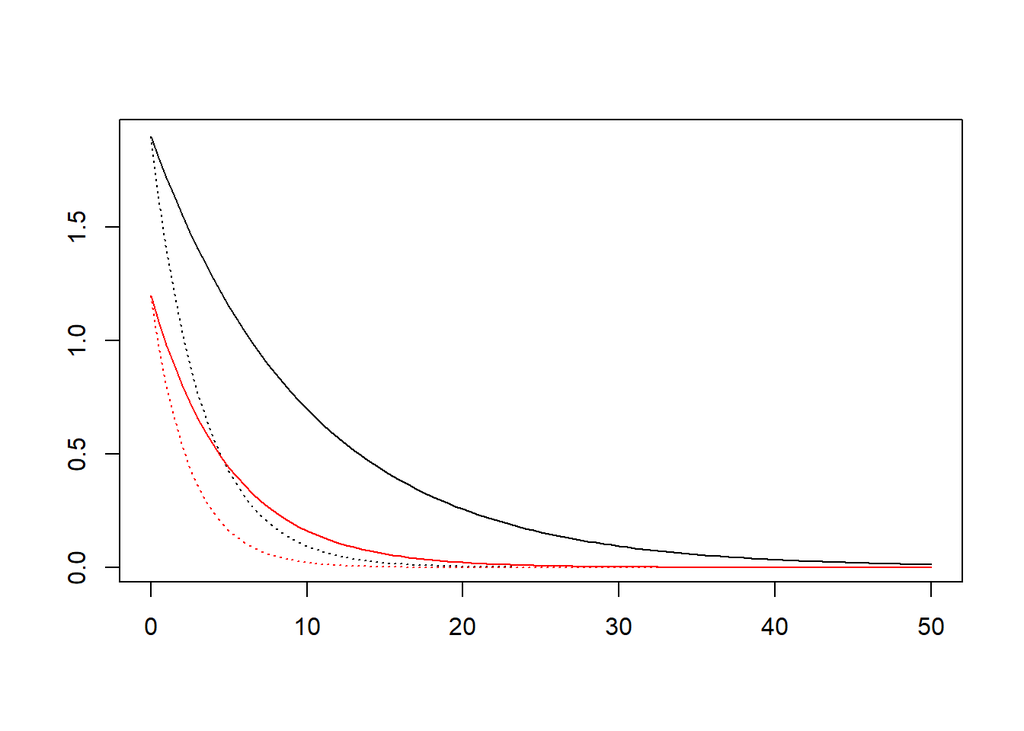

```r
{curve(
  exp_fun(x, 1.9, 0.1),  from = 0, to = 50,
  add = FALSE,
  main = "Exponential Function",

  ann = FALSE, axes = TRUE, ylab = "f(x)"); box()

curve(exp_fun(x, 1.9, 0.3), add = TRUE, lty = 3)

curve(exp_fun(x, 1.2, 0.2), add = TRUE, col="red")

curve(exp_fun(x, 1.2, 0.4), add = TRUE, lty = 3, col="red")
}
```

##**Q3 (2 pts.): Observe how the curves vary as you change the two parameters’ values.** **Qualitatively describe what happens to the curve as you vary parameter a**

Parameter a determines the intial height/ start point on the y-axis of the exponential curve. Higher values of parameter a cause higher initial values of the curve.

##**Q4 (2 pts): Observe how the curves vary as you change the two parameters’ values.** **Qualitatively describe what happens to the curve as you vary parameter b**

Parameter b determines how steeply the curve declines. Higher values cause the curve to decline more steeply, lower values cause a more gradual decline in the y-values.

##**Q5: (4 pts.): In your lab report, include a single plot containing 6 Ricker curves with these parameter values:**

**curve 1: a = 25, b = 0.1, line color = black, line texture = solid** **curve 2: a = 20, b = 0.2, line color = black, line texture = dotted** **curve 3: a = 10, b = 0.2, line color = black, line texture = dotted** **curve 4: a = 75, b = 0.3, line color = red, line texture = solid** **curve 5: a = 50, b = 0.3, line color = red, line texture = dotted** **curve 6: a = 40, b = 0.3, line color = red, line texture = dotted**

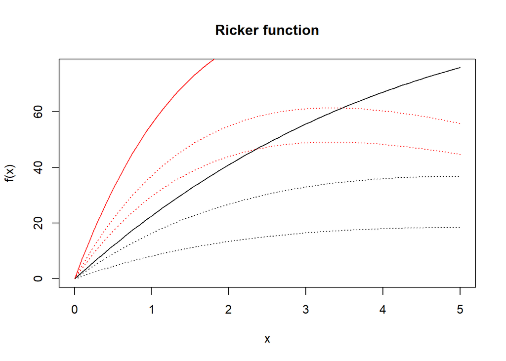

```r
{curve(
  ricker_fun(x, 25, 0.1),
  from = 0, to = 5, add = FALSE,
  main = "Ricker function",
  ylab = "f(x)", xlab = "x")
  curve(ricker_fun(x, 20, 0.2), add = TRUE, lty = 3)
    curve(ricker_fun(x, 10, 0.2), add = TRUE, lty = 3)
     curve(ricker_fun(x, 75, 0.3), add = TRUE, col = "red")
     curve(ricker_fun(x, 50, 0.3), add = TRUE, lty = 3, col = "red")
     curve(ricker_fun(x, 40, 0.3), add = TRUE, lty = 3, col = "red")}
```

##**Q6 (2 pts.): Observe how the curves vary as you change the two parameters’ values. Qualitatively describe what happens to the curve as you vary parameter a**

As you vary parameter a the rate at which the curve increases (slope) changes. At higher values of parameter a the curve increases to higher y-values more rapidly. For example a curve with parameter a = 50 has a higher y-value at x= 1 compared with a curve with parameter a = 40.

##**Q7 (2 pts): Observe how the curves vary as you change the two parameters’ values. Qualitatively describe what happens to the curve as you vary parameter b** Parameter b seems to determine the maximum of the curve/ when the curve starts to decrease. High values of parameter b cause a decrease in y-values at lower x-values.

##**Q8 (2 pts): Linear Model.Provide the values of the slope, x1, and y1 parameters you chose. Briefly describe how you chose the values.**

I chose my x and y based on what looked like the center point of the data. I chose a negative slope because the data looks like it has a slightly decreasing trend. I chose a very, very small number for slope because the slope is very shallow.

##**Q9 (2 pts): In your lab report, include a scatterplot of the salamander data with your fitted linear model.**

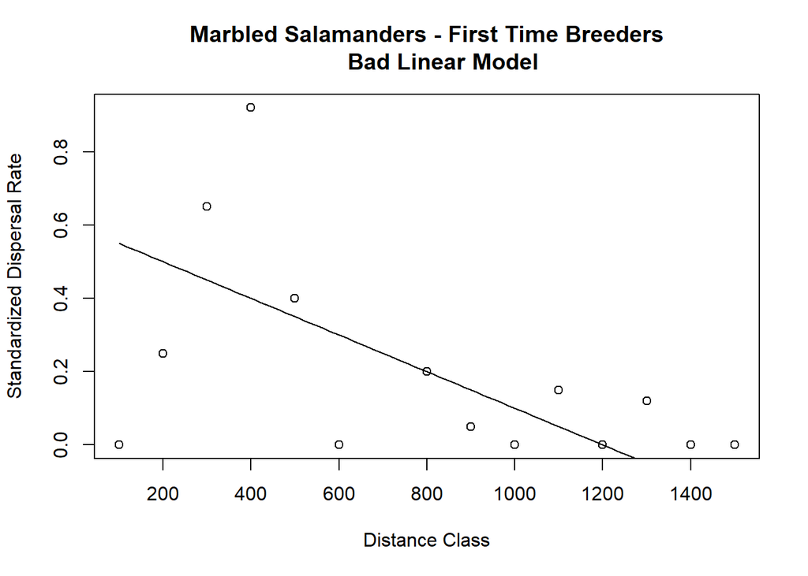

```r
plot(salamander_disp_data$disp.rate.ftb ~ salamander_disp_data$dist.class, main = "Marbled Salamanders - First Time Breeders
     Bad Linear Model", xlab = "Distance Class", ylab = "Standardized Dispersal Rate")

guess_x = 800
guess_y = 0.2
guess_slope = -0.0005
curve(line_point_slope(x, guess_x, guess_y, guess_slope), add = T)
```

##**Q10 (2 pts): Exponential Model. Provide the values of the a and b. Briefly describe how you chose the values.** I chose: a = 1 b = 0.003

I chose a value for parameter a that was high on the y-axis scale to indicate that at low x-values the curve should start very high. I chose a very low parameter b because the dispersal rate values decline slowly.

##**Q11 (2 pts): In your lab report, include a scatterplot of the salamander data with your fitted exponential model.**

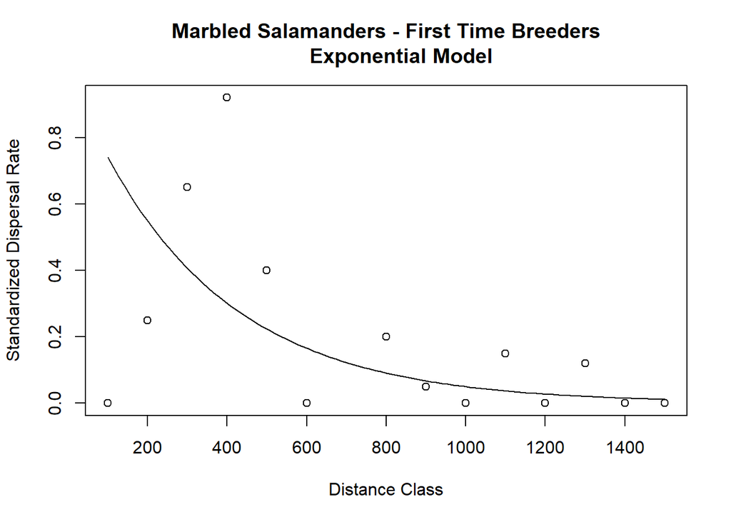

```r
plot(salamander_disp_data$disp.rate.ftb ~ salamander_disp_data$dist.class, main = "Marbled Salamanders - First Time Breeders
     Exponential Model", xlab = "Distance Class", ylab = "Standardized Dispersal Rate")
{curve(exp_fun(x, 1, 0.003), add = TRUE)}
```

##**Q12 (2 pts): Ricker Model Provide the values of the a and b. Briefly describe how you chose the values.** I chose: a = 0.0075 b = 1/325

I set my b parameter first based on the highest observed value and the form of the ricker equation. I experimented with my a value until the slope increased and decreased at a rate that closely matched the data.

##**Q13 (2 pts): In your lab report, include a scatterplot of the salamander data with your fitted ricker model.**

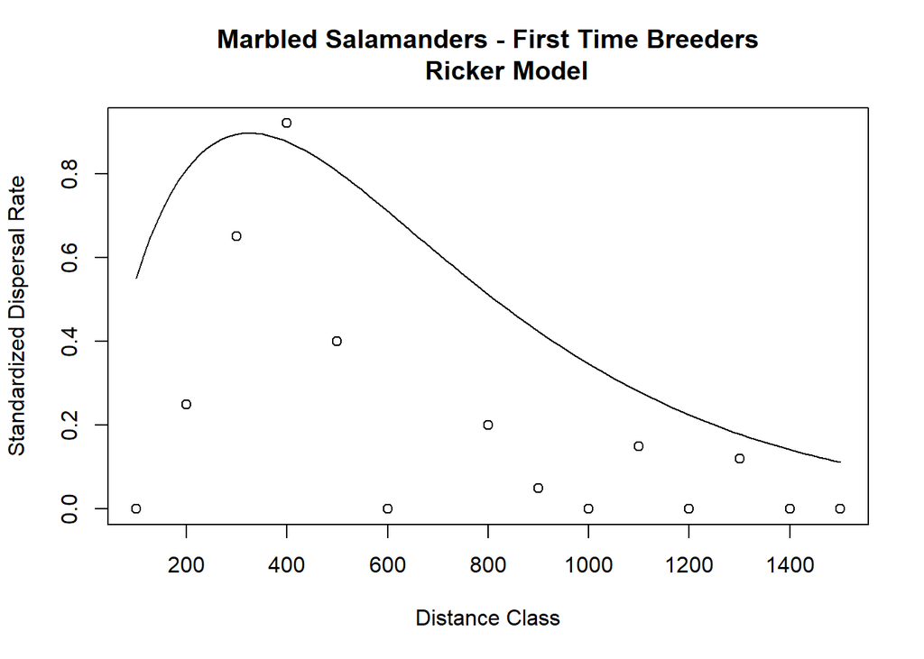

```r
plot(salamander_disp_data$disp.rate.ftb ~ salamander_disp_data$dist.class, main = "Marbled Salamanders - First Time Breeders
     Ricker Model", xlab = "Distance Class", ylab = "Standardized Dispersal Rate")
 curve(ricker_fun(x, 0.0075, 1/325), add = TRUE)
```

##**Q14 (4 pts): Show the R code you used to create your data frame of model residuals.**

```r
salamander_disp_data$linepred = line_point_slope(salamander_disp_data$dist.class, guess_x, guess_y, guess_slope)
salamander_disp_data$resids_linear = salamander_disp_data$linepred - salamander_disp_data$disp.rate.ftb

salamander_disp_data$exp_pred = exp_fun(salamander_disp_data$dist.class, 1, 0.003)
salamander_disp_data$resids_exp = salamander_disp_data$exp_pred - salamander_disp_data$disp.rate.ftb

salamander_disp_data$ricker_pred = ricker_fun(salamander_disp_data$dist.class, 0.0075, 1/325)
salamander_disp_data$resids_ricker = salamander_disp_data$ricker_pred - salamander_disp_data$disp.rate.ftb
```

##**Q15 (3 pts.): In your lab report, include histograms of the residuals for each of your three models. You may create a single figure with three panels, or include three separate figures.**

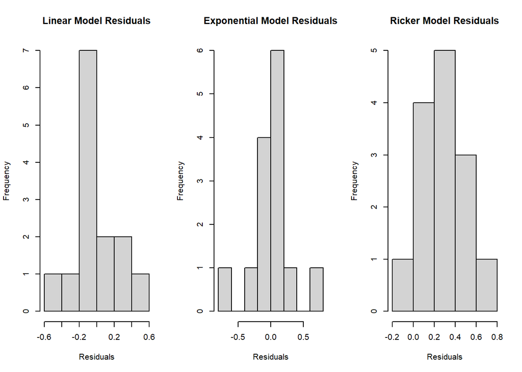

```r
par(mfrow = c(1,3))
hist(salamander_disp_data$resids_linear, xlab = "Residuals", main = "Linear Model Residuals" )
hist(salamander_disp_data$resids_exp, xlab = "Residuals", main = "Exponential Model Residuals" )
hist(salamander_disp_data$resids_ricker, xlab = "Residuals", main = "Ricker Model Residuals")
```